# IE 48B Time Series Analytics: HW2

Seyma Cakir - 2017402024

2021-11-22

```r
library(data.table)
library(ggplot2)
library(tidyr)
require(TSrepr)
require(dplyr)
require(rpart)
library(knitr)
require(caret)
library(genlasso)
library(tidyverse)

setwd('D:\\Users\\seyma\\Documents\\GitHub\\fall21-seymacakir\\HW2')
```

```r
set.seed(488)
```

# Penalized Regression Approaches for Time Series Representation

In this study, the CBF data from [Time Series Classification Web Site](https://www.timeseriesclassification.com/dataset.php) is used for representing CBF training series using 1D Fused Lasso and regression trees. The aim is comparing two alternative adaptive piece wise constant approximation in terms of their representation ability and classification performance.

First of all, the general descriptive of data is examined.

```r
#test = read.table("CBF_TEST.txt")
train_data= as.data.table( read.table("CBF_TRAIN.txt"))
kable(head(train_data), caption = "Example of Data")
```

Example of Data

| V1 | V2 | V3 | V4 | V5 | V6 | V7 | V8 | V9 | V10 | V11 | V12 | V13 | V14 | V15 | V16 | V17 | V18 | V19 | V20 | V21 | V22 | V23 | V24 | V25 | V26 | V27 | V28 | V29 | V30 | … |
| --- | --- | --- | --- | --- | --- | --- | --- | --- | --- | --- | --- | --- | --- | --- | --- | --- | --- | --- | --- | --- | --- | --- | --- | --- | --- | --- | --- | --- | --- | --- |
| 1 | -0.4642765 | -0.5550479 | -0.8428431 | -0.8658955 | -0.9363963 | -0.8172700 | -0.2636122 | -1.2580483 | -1.2503934 | -0.9183083 | -0.9221023 | -0.9844883 | -1.2880511 | -1.1434600 | -1.0488611 | -0.3653858 | -0.6913952 | -0.9805502 | -0.9913360 | -0.8870867 | -1.1098810 | -0.7687248 | -1.0102962 | -0.8469961 | -1.3277464 | -0.7129093 | -1.2977275 | 1.3314643 | 0.9357379 | … |
| 1 | -0.8969721 | -0.6856855 | -1.3513818 | -1.4586668 | -1.1653456 | -1.4039293 | -1.8217996 | -0.8316011 | -1.0163124 | -0.8035304 | -1.2595048 | -1.1392341 | -0.8786520 | -1.5487249 | -0.9241581 | -1.3954822 | 0.7766086 | 1.1007268 | 1.1898043 | 0.3751476 | 0.9471884 | 0.8037129 | 1.1572852 | 0.8867920 | 1.0371525 | 0.8150147 | 0.7908399 | 0.5412113 | 0.8583311 | … |
| 1 | -0.4646960 | -0.5677389 | -0.0320228 | -0.6350456 | -0.6028255 | -0.2668563 | -0.2670613 | -0.9310423 | -0.4493819 | -0.7213420 | -0.3972719 | -0.9621259 | -1.4206669 | -0.7834341 | -0.4623857 | -1.1762238 | -0.5016382 | -0.5848690 | -0.5791634 | -0.9212981 | -0.7163776 | -0.5477874 | -0.9908442 | -0.1464663 | -0.7200348 | 1.1589760 | 0.6767154 | 1.4286689 | 1.4453657 | … |
| 3 | -0.1871898 | -0.6208077 | -0.8156607 | -0.5213980 | -0.7904229 | -0.9675174 | -1.4870063 | -0.2778871 | -0.8350747 | 0.0505910 | -0.8111684 | -1.2260083 | -0.6683604 | -0.7766806 | 0.0640617 | -1.2536498 | -0.7889905 | -0.9342218 | -1.0935950 | -0.6079042 | -0.7027280 | 0.0183227 | 2.9755749 | 2.6772836 | 2.3958002 | 1.4215092 | 1.9771750 | 2.5777637 | 1.7979973 | … |
| 2 | -1.1360166 | -1.3191953 | -1.8446238 | -0.7886918 | -0.2517154 | -1.4876032 | -0.6687641 | -0.3403604 | -1.0463815 | -0.3122135 | -1.0314417 | -1.2005780 | -0.6504760 | -1.6195842 | -0.4127513 | -1.0506705 | -1.1751243 | -0.4278380 | -1.2002837 | -0.5872654 | -1.1734667 | -0.3187656 | -1.7099666 | -1.6916216 | -1.0547829 | -1.3315449 | -0.6897819 | -0.7449905 | -0.9839099 | … |
| 2 | -0.5687087 | -0.8881180 | -0.0479766 | -0.0380361 | -0.4830683 | -1.0946887 | -0.9534529 | -0.0300069 | -0.7954546 | -0.5144546 | -0.7187614 | -0.5162723 | -1.0740292 | -0.4314353 | -0.7049140 | 0.0811992 | -0.1807133 | -0.4138054 | -1.2541398 | 0.6286127 | 0.1092569 | -0.4035245 | 0.2984898 | -1.0170097 | 0.1060293 | -0.3239378 | -0.8826327 | -0.0782098 | -0.4767338 | … |

As seen above, the first column is reperesent class of the times series, and the other variables is the values during the time for each time series. Therefore, the data is melt as the first column represent ID of time series, second column represents class indicator, third column represents the time, finally last column shows the time series observation of the time series with each has x id at y time.

```r
setnames(train_data,'V1','class')
train_data=train_data[order(class)]
train_data$class = as.factor(train_data$class)
train_data[,id:=1:.N]
# melt the data for long format
long_train=melt(train_data,id.vars=c('id','class'))
#head(long_train)

# need to get numerical part of the variable (represents time)
# using gsub to set the nonnumerical part to zero length
long_train[,time:=as.numeric(gsub("\\D", "", variable))-1]

# remove variable
long_train=long_train[,list(id,class,time,value)]
long_train=long_train[order(id,time)]

# check
head(long_train)
```

```
##    id class time      value
## 1:  1     1    1 -0.4642765
## 2:  1     1    2 -0.5550479
## 3:  1     1    3 -0.8428431
## 4:  1     1    4 -0.8658955
## 5:  1     1    5 -0.9363963
## 6:  1     1    6 -0.8172700
```

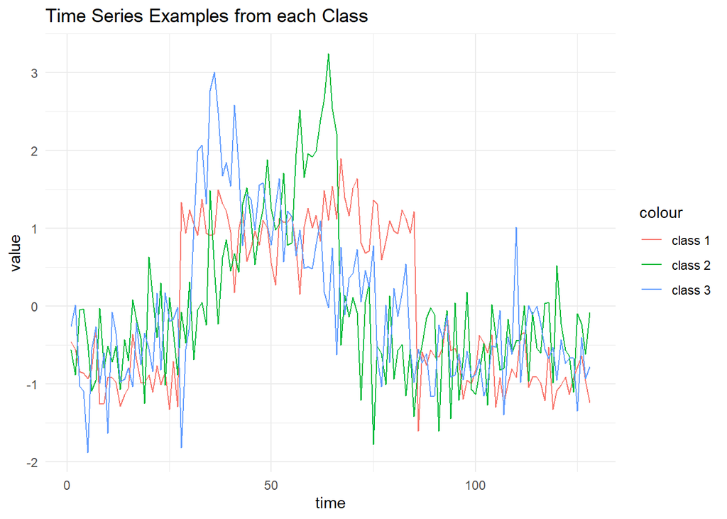

```r
ggplot() + geom_line(aes(x = long_train[id == 1]$time, y = long_train[id ==1 ]$value, color = "class 1")) +
  geom_line(aes(x = long_train[id == 12]$time, y = long_train[id ==12 ]$value, color = "class 2")) +
  geom_line(aes(x = long_train[id == 30]$time, y = long_train[id == 30 ]$value, color = "class 3")) +
  labs(
    title = "Time Series Examples from each Class",
    x = 'time',
    y = "value") +
  theme_minimal()
```

## Subtask 1: Find the time series reperesantation with 1D Fused Lasso

The [genlosso](https://cran.r-project.org/web/packages/genlasso/vignettes/article.pdf) package is used for this purpose.

At first, the first of time series is used to show detailed work.

```r
df1 = as.numeric(long_train[id==1]$value)
out1 = trendfilter(df1, ord=0)
cv1 = cv.trendfilter(out1)
```

```
## Fold 1 ... Fold 2 ... Fold 3 ... Fold 4 ... Fold 5 ...
```

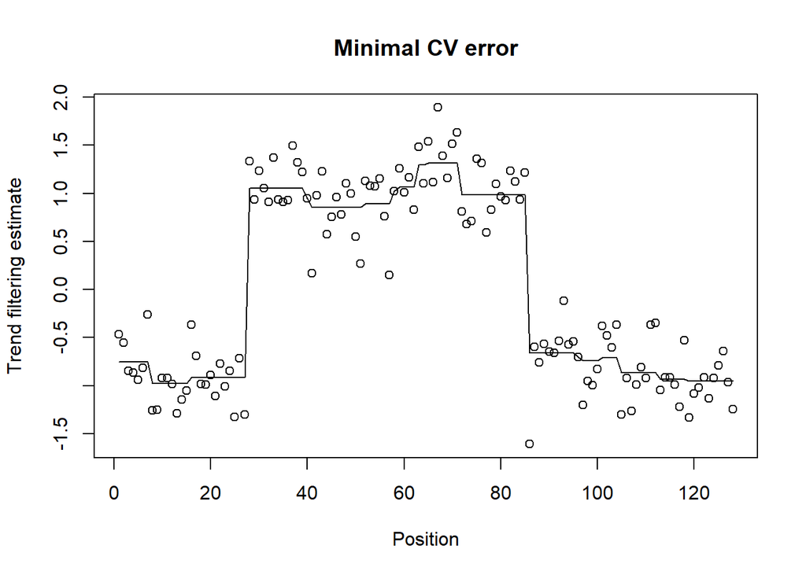

```r
plot(out1, lambda=cv1$lambda.min, main="Minimal CV error")
```

Then, the function is generated to get lambda variable minimizes the cross-validation error for a time series, dnd turns the lambda value and predictions for the model generated by using this lambda value.

```r
get_lambda <- function (data){
  out = trendfilter(data, ord=0)
  cv = cv.trendfilter(out)

  multi_return <- list("lambda" = cv$lambda.min, "predictions" = predict(out, lambda= cv$lambda.min)$fit)
}
```

The function is applied for all time series, the lambda parameter calculated for all series and recorded.

```r
lambda_values= data.table()
lambda_values[,id := 1:30]
lambda_values[, lambda:=0]

for ( i in 1:30){
  data = as.numeric(long_train[id == i ]$value)
  lambda_values[id == i]$lambda = get_lambda(data)$lambda
}
```

[output not shown]

```r
head(lambda_values)
```

```
##    id    lambda
## 1:  1 0.5087666
## 2:  2 1.5448243
## 3:  3 0.6731404
## 4:  4 1.2298325
## 5:  5 0.1550839
## 6:  6 1.2025241
```

the lambda values are plotted to see if it differs in class of time series.

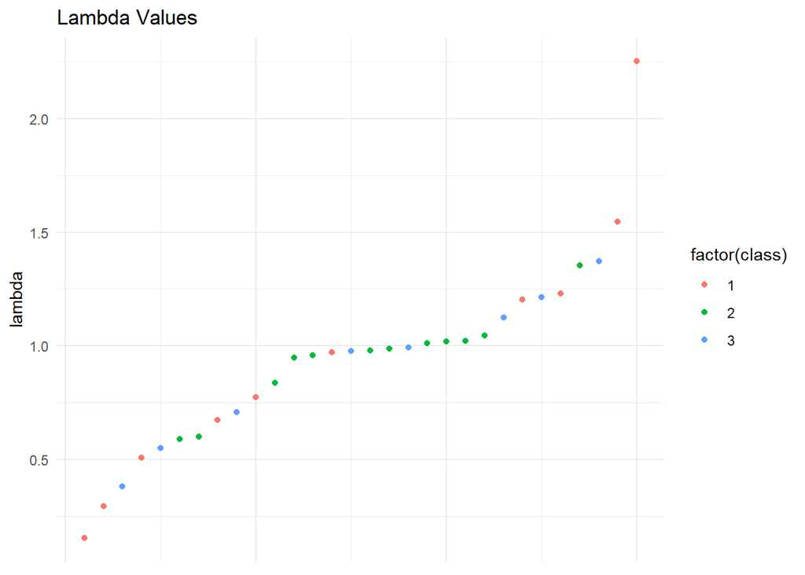

```r
 lambda_values[,class:= 0]
for (i in 1:30) {
lambda_values$class[i] = long_train[id ==i]$class[i]
}
lambda_values = as.data.table(lambda_values)


ggplot(lambda_values[order(lambda)], aes(x = 1:30, y = lambda, color = factor( class))) + geom_point() +
  labs(
  title = "Lambda Values"
  ) +
  theme_minimal() +
  theme(axis.line=element_blank(),axis.text.x=element_blank(),
          axis.title.x=element_blank())
```

However, the grapgh shows that lambda values are not distinct by class.

## Subtask 2: Find the time series reperesantation with Regression Tree

In this task, the time series are represented with rpart regression tree. The parameters of trees are determined as complexity parameter to zero, minsplit to 20 and minbucket to 10 and the suitable max depth parameter is searched by cross-validation approach. It is used 1,2,3,4,5,6,7,8,9, and 10 as maxdepth parameters.

```r
find_max_depth <- function(folds,df){

results <- matrix(0,nrow = 10, ncol= 10)
results <- as.data.table(results)
setnames(results, colnames(results), as.character(c(1:10)))

for (j in 1:10){
# in this loop different max_depth values are trained.
for (i in 1:10) {
# for this loop the max depth value is trained for 10 different data set and evaluated.
  train <- df[-folds[[i]]]
  test <- df[folds[[i]]]

  model <- rpart(value~time, data= train, method= "anova",control= rpart.control(minsplit = 20, minbucket = 10, cp= 0, maxdepth = j))
  results[i,j] <-(mse(predict(model,test), test$value))

}
}
results[,k:= 1:10]

multi_return <- list("average_mse" = results[,lapply(.SD,mean)],"max_depth" = which.min(results[,lapply(.SD,mean)]),"matrix" = results )

return(multi_return)

}
```

The first time series is examined below and the other time series also calculated by using same approach.

```r
df = long_train[id == 1 ]
folds <- createFolds(df$value, k=10)
kable(find_max_depth(folds,df)$matrix[,c(11,1:10)], caption = "the MSE values for each max depth paramater for each fold. ")
```

the MSE values for each max depth paramater for each fold.

| k | 1 | 2 | 3 | 4 | 5 | 6 | 7 | 8 | 9 | 10 |
| --- | --- | --- | --- | --- | --- | --- | --- | --- | --- | --- |
| 1 | 0.9162054 | 0.1078437 | 0.1206727 | 0.1157705 | 0.1157705 | 0.1157705 | 0.1157705 | 0.1157705 | 0.1157705 | 0.1157705 |
| 2 | 0.7908241 | 0.1754561 | 0.1692761 | 0.1346826 | 0.1346826 | 0.1346826 | 0.1346826 | 0.1346826 | 0.1346826 | 0.1346826 |
| 3 | 0.6030002 | 0.4527549 | 0.4117310 | 0.4931809 | 0.4931809 | 0.4931809 | 0.4931809 | 0.4931809 | 0.4931809 | 0.4931809 |
| 4 | 0.4560729 | 0.1908461 | 0.1860195 | 0.1888298 | 0.1888298 | 0.1888298 | 0.1888298 | 0.1888298 | 0.1888298 | 0.1888298 |
| 5 | 0.5167037 | 0.1005819 | 0.1102141 | 0.1089881 | 0.1089881 | 0.1089881 | 0.1089881 | 0.1089881 | 0.1089881 | 0.1089881 |
| 6 | 1.2445933 | 0.3626658 | 0.3577849 | 0.3613477 | 0.3613477 | 0.3613477 | 0.3613477 | 0.3613477 | 0.3613477 | 0.3613477 |
| 7 | 0.8566254 | 0.0594831 | 0.0579435 | 0.0678964 | 0.0678964 | 0.0678964 | 0.0678964 | 0.0678964 | 0.0678964 | 0.0678964 |
| 8 | 0.4069661 | 0.0934760 | 0.0753822 | 0.0849012 | 0.0849012 | 0.0849012 | 0.0849012 | 0.0849012 | 0.0849012 | 0.0849012 |
| 9 | 0.6954017 | 0.0851928 | 0.0993444 | 0.1045068 | 0.1045068 | 0.1045068 | 0.1045068 | 0.1045068 | 0.1045068 | 0.1045068 |
| 10 | 0.3693179 | 0.0966836 | 0.1016382 | 0.1068070 | 0.1066462 | 0.1066462 | 0.1066462 | 0.1066462 | 0.1066462 | 0.1066462 |

By taking the avarage of MSE values for each max depth value, if the max depth paramater has the minumum average MSE value it is selected.

**Average closs-validation MSE values for the first timer series**

```r
find_max_depth(folds,df)$average_mse[,1:10]
```

```
##            1         2         3         4        5        6        7        8
## 1: 0.6855711 0.1724984 0.1690007 0.1766911 0.176675 0.176675 0.176675 0.176675
##           9       10
## 1: 0.176675 0.176675
```

the minumum mse value is obtained by max depth parameter equals 3.

the predicted values vs. real variable with parameter maxdepth = 3 for time series 1 is plotted to see how the rpart represtantation is works.

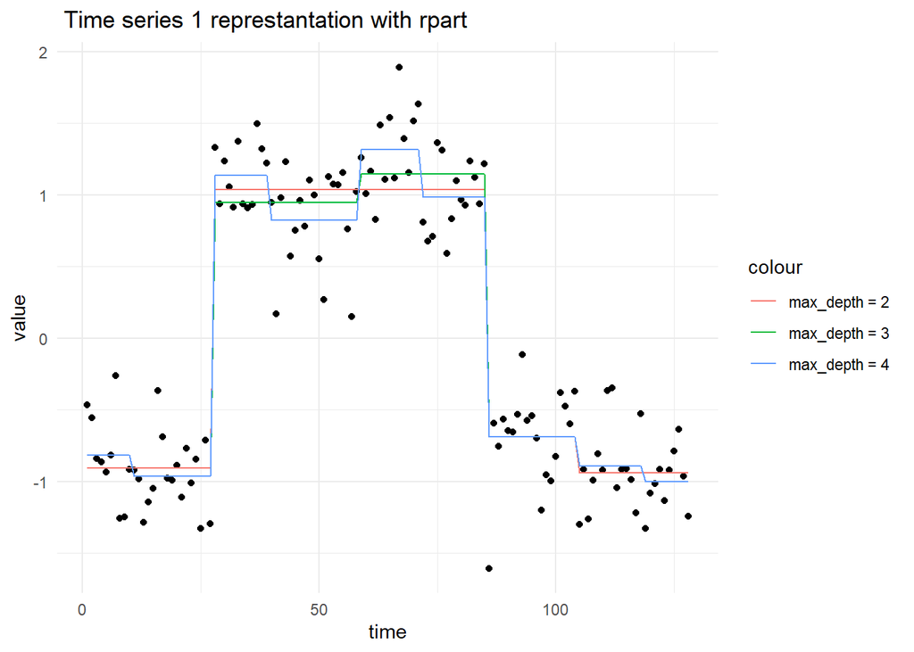

```r
model2 <- rpart(value~time, data= df, method= "anova",control= rpart.control(minsplit = 20, minbucket = 10, cp= 0, maxdepth =2 ))
model3 <- rpart(value~time, data= df, method= "anova",control= rpart.control(minsplit = 20, minbucket = 10, cp= 0, maxdepth =3 ))
model4 <- rpart(value~time, data= df, method= "anova",control= rpart.control(minsplit = 20, minbucket = 10, cp= 0, maxdepth =4 ))


ggplot(df, aes( x = time, y = value), color = "Real_Values" )+ geom_point() + geom_line(aes( x = df$time, y = predict(model2), color = "max_depth = 2")) +
  geom_line(aes( x = df$time, y = predict(model3), color = "max_depth = 3")) +
  geom_line(aes( x = df$time, y = predict(model4), color = "max_depth = 4 ")) +
  labs(
    title = " Time series 1 represtantation with rpart"
    ) + theme_minimal()
```

And the process is repated for all time series.

```r
max_depth <- data.table("id" = 1:30)
max_depth[, max_depth:= 30]

for (i in 1:30){

  df = long_train[id == i ]
  folds <- createFolds(df$value, k=10)

  max_depth[id==i]$max_depth <- find_max_depth(folds,df)$max_depth

}

max_depth[, class:= as.factor(lambda_values$class)]

head(max_depth)
```

```
##    id max_depth class
## 1:  1         3     1
## 2:  2         2     1
## 3:  3         2     1
## 4:  4         2     1
## 5:  5         2     1
## 6:  6         4     1
```

## Subtask 3: Compare two represetation by MSE

To calculate Fused Lasso MSEs values, the get_lambda function is created in subtask 1 which allows lambda values minimizes the cross-validation error and the predictions were made for each time series.

```r
mse_fusedlasso <- as.data.table(c(1:30))
mse_fusedlasso[,mse:= 'NA']
mse_fusedlasso[,class:= 'NA']
fusedlasso_predictions <- list()

for ( i in 1:30){
mse_fusedlasso[V1 == i]$mse <- mse(long_train[id == i]$value, get_lambda(long_train[id==i]$value)$prediction)
fusedlasso_predictions[[i]] <- get_lambda(long_train[id==i]$value)$prediction
mse_fusedlasso$class[i] <- long_train[id==i]$class[1]
}
```

[output not shown]

**MSE values by Fussed Lasso**

```r
mse_fusedlasso
```

```
##     V1                mse class
##  1:  1 0.0710239941932559     1
##  2:  2  0.106017823603284     1
##  3:  3 0.0741570076520662     1
##  4:  4  0.105591154988158     1
##  5:  5 0.0277490941982365     1
##  6:  6  0.135960256867436     1
##  7:  7 0.0749067774462681     1
##  8:  8 0.0945220729475966     1
##  9:  9  0.133589236865948     1
## 10: 10 0.0543543032230271     1
## 11: 11  0.153073451397691     2
## 12: 12  0.197775395961002     2
## 13: 13  0.141169614151907     2
## 14: 14  0.156794611031777     2
```

[output cut: 17 more lines]

```r
mse_rpart <- as.data.table(c(1:30))
mse_rpart[,mse:= 'NA']
rpart_predictions <-list()
mse_rpart[,class:= 'NA']

for (i in 1:30){

model <- rpart(value~time, data= long_train[id == i] , method= "anova",control= rpart.control(minsplit = 20, minbucket = 10, cp= 0, maxdepth =  max_depth[id==1]$max_depth))
rpart_predictions[[i]] <- predict(model)
mse_rpart[V1 == i]$mse <- mse(long_train[id == i]$value, predict(model))
mse_rpart$class[i] <- as.factor(long_train[id==i]$class[1])

}
```

**MSE values by rpart representation**

```r
mse_rpart
```

```
##     V1                mse class
##  1:  1 0.0873709783212773     1
##  2:  2  0.100177651096116     1
##  3:  3 0.0847508555316539     1
##  4:  4  0.106886929243742     1
##  5:  5 0.0982759243173647     1
##  6:  6  0.242332074607038     1
##  7:  7 0.0744001549961969     1
##  8:  8 0.0991828857048298     1
##  9:  9  0.124230438876128     1
## 10: 10 0.0927617723396269     1
## 11: 11  0.191571352851843     2
## 12: 12  0.215665775785824     2
## 13: 13  0.199462533476438     2
## 14: 14  0.174698752095343     2
```

[output cut: 17 more lines]

The mse values comparing with box-plot below to see model performances.

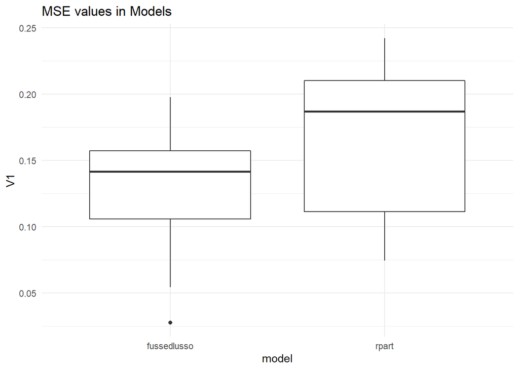

```r
mse_values <- as.data.table(as.numeric(c(mse_fusedlasso$mse,mse_rpart$mse)))

mse_values[,model:= rep(c("fussedlusso","rpart"), each = 30)]

 ggplot(mse_values, aes(x = model, y = V1)) + geom_boxplot() + labs( title = "MSE values in Models", xlab = "model", ylab = "mse values") + theme_minimal()
```

By observing box-plot above, it can be said that fussed lusso model mse values is lower than rpart model in general, if the goal was predict time series may be fussed lasso model can be more successful.

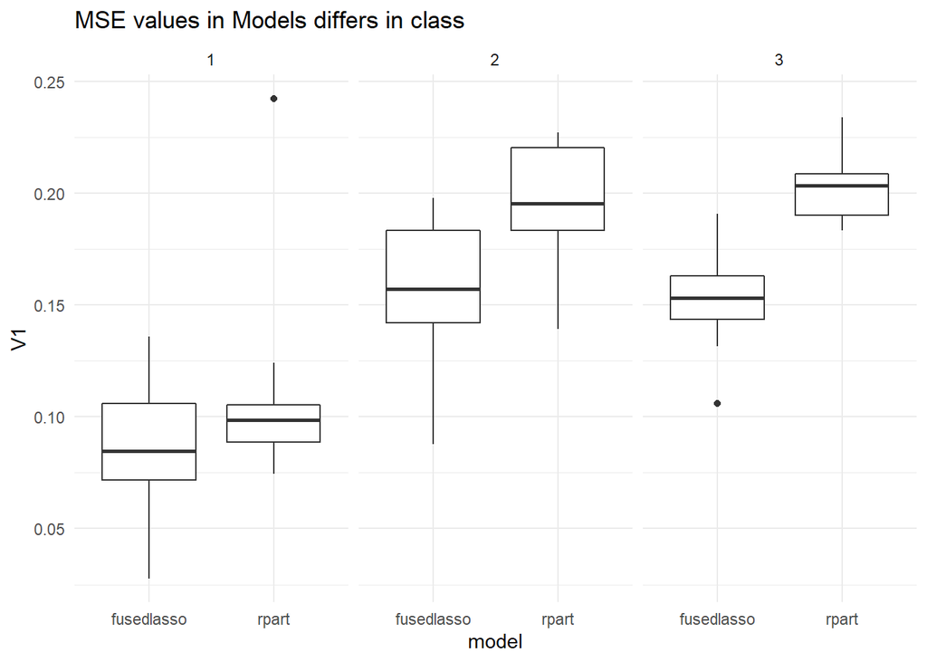

```r
mse_values <- as.data.table(as.numeric(c(mse_fusedlasso$mse,mse_rpart$mse)))

mse_values[,model:= rep(c("fusedlasso","rpart"), each = 30)]
mse_values[, class:= as.factor(c(mse_fusedlasso$class,mse_rpart$class))]

 ggplot(mse_values, aes(x = model, y = V1)) + geom_boxplot() + labs( title = "MSE values in Models differs in class", xlab = "model", ylab = "mse values") + theme_minimal() + facet_wrap(~class)
```

As seen above, fused lasso is better for all classes.

## Subtask 4: Comparison based on the Accuracy of 1-NN Classifier

In this part of the study, the class of time series are predicted by using euclidian distance.

At first, the time series are predicted by calculating each point distabce from another time series and the closest time series assumed that has the same time series class.

```r
trainclass= train_data[,1]
traindata=train_data[,2:ncol(train_data)]
dim(traindata)
```

```
## [1]  30 129
```

The code chunk below shows the 1-NN classification approach by using euclidean distance to predict first time series classification.

```r
euc_dist=dist(traindata)
euc_dist=as.matrix(euc_dist)
large_number=100000
diag(euc_dist)=large_number
neighborhood=order(euc_dist[1,])
neighborhood
```

```
##  [1]  5  4  2  3  8 10  6  7  9 14 12 13 15 11 16 17 18 22 19 21 25 20 23 24 27
## [26] 26 28 29 30  1
```

```r
neighbor=neighborhood[1]
prediction=trainclass[neighbor]

prediction
```

```
##    class
## 1:     1
```

```r
neighborhood=apply(euc_dist,1,order)
predicted= trainclass[neighborhood[1,]]
```

**Confusion Matrix for rawdata**

```r
confusionMatrix(data=predicted$class, reference = trainclass$class)
```

```
## Confusion Matrix and Statistics
##
##           Reference
## Prediction  1  2  3
##          1 10  0  0
##          2  0 11  0
##          3  0  1  8
##
## Overall Statistics
##
##                Accuracy : 0.9667
##                  95% CI : (0.8278, 0.9992)
##     No Information Rate : 0.4
##     P-Value [Acc > NIR] : 5.303e-11
##
##                   Kappa : 0.9497
##
##  Mcnemar's Test P-Value : NA
##
## Statistics by Class:
##
##                      Class: 1 Class: 2 Class: 3
## Sensitivity            1.0000   0.9167   1.0000
## Specificity            1.0000   1.0000   0.9545
## Pos Pred Value         1.0000   1.0000   0.8889
## Neg Pred Value         1.0000   0.9474   1.0000
## Prevalence             0.3333   0.4000   0.2667
## Detection Rate         0.3333   0.3667   0.2667
## Detection Prevalence   0.3333   0.3667   0.3000
## Balanced Accuracy      1.0000   0.9583   0.9773
```

**Classification by Rpart**

```r
rparttraindata <- t(as.data.table(rpart_predictions))
euc_distRPART=dist(rparttraindata)
euc_distRPART=as.matrix(euc_distRPART)
large_number=100000
diag(euc_distRPART)=large_number

neighborhoodRPART=apply(euc_distRPART,1,order)
predictedrpart= trainclass[neighborhoodRPART[1,]]
```

**Confusion Matrix for rpart time series representation**

```r
confusionMatrix(data=predictedrpart$class, reference = trainclass$class)
```

```
## Confusion Matrix and Statistics
##
##           Reference
## Prediction  1  2  3
##          1  8  1  1
##          2  0 11  0
##          3  2  0  7
##
## Overall Statistics
##
##                Accuracy : 0.8667
##                  95% CI : (0.6928, 0.9624)
##     No Information Rate : 0.4
##     P-Value [Acc > NIR] : 1.769e-07
##
##                   Kappa : 0.7987
##
##  Mcnemar's Test P-Value : NA
##
## Statistics by Class:
##
##                      Class: 1 Class: 2 Class: 3
## Sensitivity            0.8000   0.9167   0.8750
## Specificity            0.9000   1.0000   0.9091
## Pos Pred Value         0.8000   1.0000   0.7778
## Neg Pred Value         0.9000   0.9474   0.9524
## Prevalence             0.3333   0.4000   0.2667
## Detection Rate         0.2667   0.3667   0.2333
## Detection Prevalence   0.3333   0.3667   0.3000
## Balanced Accuracy      0.8500   0.9583   0.8920
```

**Classification by FusedLasso**

```r
fused_lasso_traindata <- t(as.data.table(fusedlasso_predictions))
euc_distFL=dist(fused_lasso_traindata)
euc_distFL=as.matrix(euc_distFL)
large_number=100000
diag(euc_distFL)=large_number

neighborhoodFL=apply(euc_distFL,1,order)
predictedFL= trainclass[neighborhoodFL[1,]]
```

**Confusion Matrix for Fused Lasso time series representation**

```r
confusionMatrix(data=predictedFL$class, reference = trainclass$class)
```

[output not shown]

By evaluating accuracy of all class predictions, it can be say that by using euclidean distance approach with 1-NN classification give better result by no time series representation.

## References

[Genlasso Package](https://cran.r-project.org/web/packages/genlasso/vignettes/article.pdf) [TS classification Lecture Notes By Mustafa Baydoğan](https://moodle.boun.edu.tr/mod/resource/view.php?id=505544)

### RMD

The code of my study is available from [here](https://bu-ie-48B.github.io/fall21-seymacakir/HW2/HW2.Rmd)